# Risk Factor Analysis

## Outcome Variable

**Outcome Variable:** ever_stunted

## Predictor Variables

**Intervention Variable:** nrooms

**Adjustment Set:**

- arm
- sex
- W_mage
- meducyrs
- feducyrs
- hhwealth_quart
- hfoodsec
- W_mhtcm
- W_nchldlt5
- W_parity
- impfloor
- impsan
- safeh20
- delta_sex
- delta_W_mage
- delta_meducyrs
- delta_feducyrs
- delta_hhwealth_quart
- delta_hfoodsec
- delta_W_mhtcm
- delta_W_nchldlt5
- delta_W_parity
- delta_impfloor
- delta_impsan
- delta_safeh20

## Stratifying Variables

The analysis was stratified on these variable(s):

- agecat
- studyid
- country

## Data Summary

| agecat | studyid | country | nrooms | ever_stunted | n_cell | n |
| --- | --- | --- | --- | --- | --- | --- |
| 0-24 months | ki0047075b-MAL-ED | BANGLADESH | 4+ | 0 | 8 | 242 |
| 0-24 months | ki0047075b-MAL-ED | BANGLADESH | 4+ | 1 | 4 | 242 |
| 0-24 months | ki0047075b-MAL-ED | BANGLADESH | 1 | 0 | 56 | 242 |
| 0-24 months | ki0047075b-MAL-ED | BANGLADESH | 1 | 1 | 96 | 242 |
| 0-24 months | ki0047075b-MAL-ED | BANGLADESH | 2 | 0 | 19 | 242 |
| 0-24 months | ki0047075b-MAL-ED | BANGLADESH | 2 | 1 | 31 | 242 |
| 0-24 months | ki0047075b-MAL-ED | BANGLADESH | 3 | 0 | 11 | 242 |
| 0-24 months | ki0047075b-MAL-ED | BANGLADESH | 3 | 1 | 17 | 242 |
| 0-24 months | ki0047075b-MAL-ED | BRAZIL | 4+ | 0 | 99 | 210 |
| 0-24 months | ki0047075b-MAL-ED | BRAZIL | 4+ | 1 | 28 | 210 |
| 0-24 months | ki0047075b-MAL-ED | BRAZIL | 1 | 0 | 4 | 210 |
| 0-24 months | ki0047075b-MAL-ED | BRAZIL | 1 | 1 | 0 | 210 |
| 0-24 months | ki0047075b-MAL-ED | BRAZIL | 2 | 0 | 16 | 210 |
| 0-24 months | ki0047075b-MAL-ED | BRAZIL | 2 | 1 | 4 | 210 |
| 0-24 months | ki0047075b-MAL-ED | BRAZIL | 3 | 0 | 42 | 210 |
| 0-24 months | ki0047075b-MAL-ED | BRAZIL | 3 | 1 | 17 | 210 |
| 0-24 months | ki0047075b-MAL-ED | INDIA | 4+ | 0 | 9 | 235 |
| 0-24 months | ki0047075b-MAL-ED | INDIA | 4+ | 1 | 16 | 235 |
| 0-24 months | ki0047075b-MAL-ED | INDIA | 1 | 0 | 39 | 235 |
| 0-24 months | ki0047075b-MAL-ED | INDIA | 1 | 1 | 45 | 235 |
| 0-24 months | ki0047075b-MAL-ED | INDIA | 2 | 0 | 21 | 235 |
| 0-24 months | ki0047075b-MAL-ED | INDIA | 2 | 1 | 57 | 235 |
| 0-24 months | ki0047075b-MAL-ED | INDIA | 3 | 0 | 22 | 235 |
| 0-24 months | ki0047075b-MAL-ED | INDIA | 3 | 1 | 26 | 235 |
| 0-24 months | ki0047075b-MAL-ED | NEPAL | 4+ | 0 | 88 | 236 |
| 0-24 months | ki0047075b-MAL-ED | NEPAL | 4+ | 1 | 43 | 236 |
| 0-24 months | ki0047075b-MAL-ED | NEPAL | 1 | 0 | 33 | 236 |
| 0-24 months | ki0047075b-MAL-ED | NEPAL | 1 | 1 | 19 | 236 |
| 0-24 months | ki0047075b-MAL-ED | NEPAL | 2 | 0 | 22 | 236 |
| 0-24 months | ki0047075b-MAL-ED | NEPAL | 2 | 1 | 9 | 236 |

[output cut: 354 more lines]

The following strata were considered:

- agecat: 0-24 months, studyid: ki0047075b-MAL-ED, country: BANGLADESH
- agecat: 0-24 months, studyid: ki0047075b-MAL-ED, country: BRAZIL
- agecat: 0-24 months, studyid: ki0047075b-MAL-ED, country: INDIA
- agecat: 0-24 months, studyid: ki0047075b-MAL-ED, country: NEPAL
- agecat: 0-24 months, studyid: ki0047075b-MAL-ED, country: PERU
- agecat: 0-24 months, studyid: ki0047075b-MAL-ED, country: SOUTH AFRICA
- agecat: 0-24 months, studyid: ki0047075b-MAL-ED, country: TANZANIA, UNITED REPUBLIC OF
- agecat: 0-24 months, studyid: ki1000108-CMC-V-BCS-2002, country: INDIA
- agecat: 0-24 months, studyid: ki1000108-IRC, country: INDIA
- agecat: 0-24 months, studyid: ki1017093b-PROVIDE, country: BANGLADESH
- agecat: 0-24 months, studyid: ki1017093c-NIH-Crypto, country: BANGLADESH
- agecat: 0-24 months, studyid: ki1113344-GMS-Nepal, country: NEPAL
- agecat: 0-24 months, studyid: ki1114097-CONTENT, country: PERU
- agecat: 0-24 months, studyid: ki1135781-COHORTS, country: INDIA
- agecat: 0-24 months, studyid: kiGH5241-JiVitA-3, country: BANGLADESH
- agecat: 0-24 months, studyid: kiGH5241-JiVitA-4, country: BANGLADESH
- agecat: 0-6 months, studyid: ki0047075b-MAL-ED, country: BANGLADESH
- agecat: 0-6 months, studyid: ki0047075b-MAL-ED, country: BRAZIL
- agecat: 0-6 months, studyid: ki0047075b-MAL-ED, country: INDIA
- agecat: 0-6 months, studyid: ki0047075b-MAL-ED, country: NEPAL
- agecat: 0-6 months, studyid: ki0047075b-MAL-ED, country: PERU
- agecat: 0-6 months, studyid: ki0047075b-MAL-ED, country: SOUTH AFRICA
- agecat: 0-6 months, studyid: ki0047075b-MAL-ED, country: TANZANIA, UNITED REPUBLIC OF
- agecat: 0-6 months, studyid: ki1000108-CMC-V-BCS-2002, country: INDIA
- agecat: 0-6 months, studyid: ki1000108-IRC, country: INDIA
- agecat: 0-6 months, studyid: ki1017093b-PROVIDE, country: BANGLADESH
- agecat: 0-6 months, studyid: ki1017093c-NIH-Crypto, country: BANGLADESH
- agecat: 0-6 months, studyid: ki1113344-GMS-Nepal, country: NEPAL
- agecat: 0-6 months, studyid: ki1114097-CONTENT, country: PERU
- agecat: 0-6 months, studyid: ki1135781-COHORTS, country: INDIA
- agecat: 0-6 months, studyid: kiGH5241-JiVitA-3, country: BANGLADESH
- agecat: 0-6 months, studyid: kiGH5241-JiVitA-4, country: BANGLADESH
- agecat: 6-24 months, studyid: ki0047075b-MAL-ED, country: BANGLADESH
- agecat: 6-24 months, studyid: ki0047075b-MAL-ED, country: BRAZIL
- agecat: 6-24 months, studyid: ki0047075b-MAL-ED, country: INDIA
- agecat: 6-24 months, studyid: ki0047075b-MAL-ED, country: NEPAL
- agecat: 6-24 months, studyid: ki0047075b-MAL-ED, country: PERU
- agecat: 6-24 months, studyid: ki0047075b-MAL-ED, country: SOUTH AFRICA
- agecat: 6-24 months, studyid: ki0047075b-MAL-ED, country: TANZANIA, UNITED REPUBLIC OF
- agecat: 6-24 months, studyid: ki1000108-CMC-V-BCS-2002, country: INDIA
- agecat: 6-24 months, studyid: ki1000108-IRC, country: INDIA
- agecat: 6-24 months, studyid: ki1017093b-PROVIDE, country: BANGLADESH
- agecat: 6-24 months, studyid: ki1017093c-NIH-Crypto, country: BANGLADESH
- agecat: 6-24 months, studyid: ki1113344-GMS-Nepal, country: NEPAL
- agecat: 6-24 months, studyid: ki1114097-CONTENT, country: PERU
- agecat: 6-24 months, studyid: ki1135781-COHORTS, country: INDIA
- agecat: 6-24 months, studyid: kiGH5241-JiVitA-3, country: BANGLADESH
- agecat: 6-24 months, studyid: kiGH5241-JiVitA-4, country: BANGLADESH

### Dropped Strata

Some strata were dropped due to rare outcomes:

- agecat: 0-24 months, studyid: ki0047075b-MAL-ED, country: BANGLADESH
- agecat: 0-24 months, studyid: ki0047075b-MAL-ED, country: BRAZIL
- agecat: 0-24 months, studyid: ki0047075b-MAL-ED, country: PERU
- agecat: 0-24 months, studyid: ki1000108-CMC-V-BCS-2002, country: INDIA
- agecat: 0-24 months, studyid: ki1000108-IRC, country: INDIA
- agecat: 0-6 months, studyid: ki0047075b-MAL-ED, country: BANGLADESH
- agecat: 0-6 months, studyid: ki0047075b-MAL-ED, country: BRAZIL
- agecat: 0-6 months, studyid: ki0047075b-MAL-ED, country: NEPAL
- agecat: 0-6 months, studyid: ki1017093b-PROVIDE, country: BANGLADESH
- agecat: 6-24 months, studyid: ki0047075b-MAL-ED, country: BANGLADESH
- agecat: 6-24 months, studyid: ki0047075b-MAL-ED, country: BRAZIL
- agecat: 6-24 months, studyid: ki0047075b-MAL-ED, country: NEPAL
- agecat: 6-24 months, studyid: ki0047075b-MAL-ED, country: PERU
- agecat: 6-24 months, studyid: ki0047075b-MAL-ED, country: SOUTH AFRICA
- agecat: 6-24 months, studyid: ki0047075b-MAL-ED, country: TANZANIA, UNITED REPUBLIC OF
- agecat: 6-24 months, studyid: ki1000108-CMC-V-BCS-2002, country: INDIA
- agecat: 6-24 months, studyid: ki1000108-IRC, country: INDIA
- agecat: 6-24 months, studyid: ki1017093b-PROVIDE, country: BANGLADESH
- agecat: 6-24 months, studyid: ki1114097-CONTENT, country: PERU

## Methods Detail

We’re interested in the causal parameters $E[Y_a]$ for all values of $a \in \mathcal{A}$. These parameters represent the mean outcome if, possibly contrary to fact, we intervened to set all units to have $A=a$. Under the randomization and positivity assumptions, these are identified by the statistical parameters $\psi_a=E_W[E_{Y|A,W}(Y|A=a,W)]$. In addition, we’re interested in the mean of $Y$, $E[Y]$ under no intervention (the observed mean). We will estimate these parameters by using SuperLearner to fit the relevant likelihood factors – $E_{Y|A,W}(Y|A=a,W)$ and $p(A=a|W)$, and then updating our likelihood fit using a joint TMLE.

For unadjusted analyses ($W=\{\}$), initial likelihoods were estimated using Lrnr_glm to estimate the simple $E(Y|A)$ and Lrnr_mean to estimate $p(A)$. For adjusted analyses, a small library containing Lrnr_glmnet, Lrnr_xgboost, and Lrnr_mean was used.

Having estimated these parameters, we will then use the delta method to estimate relative risks and attributable risks relative to a prespecified baseline level of $A$.

# Results Detail

## Results Plots

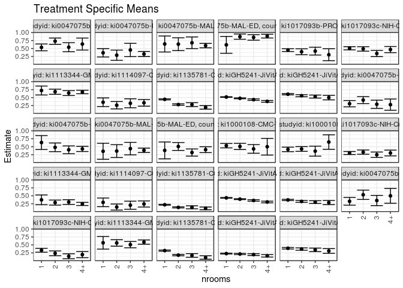

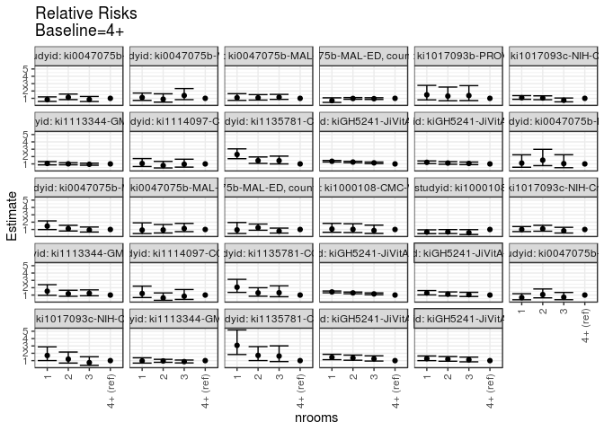

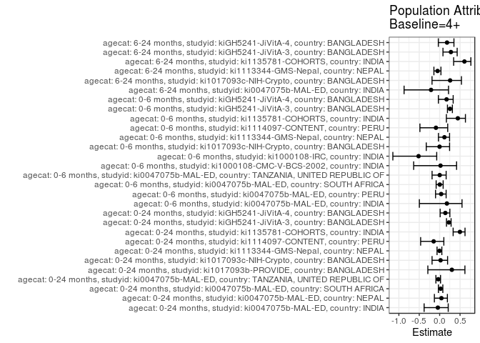

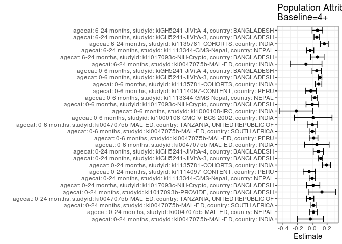

## Results Table

### Parameter: TSM

| agecat | studyid | country | intervention_level | baseline_level | estimate | ci_lower | ci_upper |
| --- | --- | --- | --- | --- | --- | --- | --- |
| 0-24 months | ki0047075b-MAL-ED | INDIA | 4+ | NA | 0.6400000 | 0.4514418 | 0.8285582 |
| 0-24 months | ki0047075b-MAL-ED | INDIA | 1 | NA | 0.5357143 | 0.4288350 | 0.6425936 |
| 0-24 months | ki0047075b-MAL-ED | INDIA | 2 | NA | 0.7307692 | 0.6321233 | 0.8294152 |
| 0-24 months | ki0047075b-MAL-ED | INDIA | 3 | NA | 0.5416667 | 0.4004096 | 0.6829238 |
| 0-24 months | ki0047075b-MAL-ED | NEPAL | 4+ | NA | 0.3282443 | 0.2476621 | 0.4088264 |
| 0-24 months | ki0047075b-MAL-ED | NEPAL | 1 | NA | 0.3653846 | 0.2342254 | 0.4965439 |
| 0-24 months | ki0047075b-MAL-ED | NEPAL | 2 | NA | 0.2903226 | 0.1301972 | 0.4504480 |
| 0-24 months | ki0047075b-MAL-ED | NEPAL | 3 | NA | 0.4545455 | 0.2460355 | 0.6630554 |
| 0-24 months | ki0047075b-MAL-ED | SOUTH AFRICA | 4+ | NA | 0.5918367 | 0.5228946 | 0.6607788 |
| 0-24 months | ki0047075b-MAL-ED | SOUTH AFRICA | 1 | NA | 0.6428571 | 0.3913740 | 0.8943403 |
| 0-24 months | ki0047075b-MAL-ED | SOUTH AFRICA | 2 | NA | 0.6363636 | 0.4349589 | 0.8377684 |
| 0-24 months | ki0047075b-MAL-ED | SOUTH AFRICA | 3 | NA | 0.6800000 | 0.4967879 | 0.8632121 |
| 0-24 months | ki0047075b-MAL-ED | TANZANIA, UNITED REPUBLIC OF | 4+ | NA | 0.8888889 | 0.8294995 | 0.9482783 |
| 0-24 months | ki0047075b-MAL-ED | TANZANIA, UNITED REPUBLIC OF | 1 | NA | 0.6153846 | 0.3503922 | 0.8803770 |
| 0-24 months | ki0047075b-MAL-ED | TANZANIA, UNITED REPUBLIC OF | 2 | NA | 0.8730159 | 0.7906336 | 0.9553982 |
| 0-24 months | ki0047075b-MAL-ED | TANZANIA, UNITED REPUBLIC OF | 3 | NA | 0.8484848 | 0.7618093 | 0.9351604 |
| 0-24 months | ki1017093b-PROVIDE | BANGLADESH | 4+ | NA | 0.3043478 | 0.1161668 | 0.4925288 |
| 0-24 months | ki1017093b-PROVIDE | BANGLADESH | 1 | NA | 0.4497041 | 0.4063714 | 0.4930369 |
| 0-24 months | ki1017093b-PROVIDE | BANGLADESH | 2 | NA | 0.3981481 | 0.3057605 | 0.4905358 |
| 0-24 months | ki1017093b-PROVIDE | BANGLADESH | 3 | NA | 0.4193548 | 0.2964387 | 0.5422710 |
| 0-24 months | ki1017093c-NIH-Crypto | BANGLADESH | 4+ | NA | 0.4668365 | 0.3700835 | 0.5635895 |
| 0-24 months | ki1017093c-NIH-Crypto | BANGLADESH | 1 | NA | 0.5081491 | 0.4581244 | 0.5581739 |
| 0-24 months | ki1017093c-NIH-Crypto | BANGLADESH | 2 | NA | 0.4875745 | 0.4178374 | 0.5573115 |
| 0-24 months | ki1017093c-NIH-Crypto | BANGLADESH | 3 | NA | 0.3435931 | 0.2464954 | 0.4406909 |
| 0-24 months | ki1113344-GMS-Nepal | NEPAL | 4+ | NA | 0.6767905 | 0.6222387 | 0.7313423 |
| 0-24 months | ki1113344-GMS-Nepal | NEPAL | 1 | NA | 0.7232391 | 0.5833739 | 0.8631044 |
| 0-24 months | ki1113344-GMS-Nepal | NEPAL | 2 | NA | 0.6854116 | 0.6046915 | 0.7661316 |
| 0-24 months | ki1113344-GMS-Nepal | NEPAL | 3 | NA | 0.6436175 | 0.5658935 | 0.7213415 |
| 0-24 months | ki1114097-CONTENT | PERU | 4+ | NA | 0.3361105 | 0.2319559 | 0.4402651 |
| 0-24 months | ki1114097-CONTENT | PERU | 1 | NA | 0.3547852 | 0.2187264 | 0.4908440 |

[output cut: 86 more lines]

### Parameter: E(Y)

| agecat | studyid | country | intervention_level | baseline_level | estimate | ci_lower | ci_upper |
| --- | --- | --- | --- | --- | --- | --- | --- |
| 0-24 months | ki0047075b-MAL-ED | INDIA | NA | NA | 0.6127660 | 0.5503531 | 0.6751788 |
| 0-24 months | ki0047075b-MAL-ED | NEPAL | NA | NA | 0.3432203 | 0.2825173 | 0.4039234 |
| 0-24 months | ki0047075b-MAL-ED | SOUTH AFRICA | NA | NA | 0.6070039 | 0.5471740 | 0.6668337 |
| 0-24 months | ki0047075b-MAL-ED | TANZANIA, UNITED REPUBLIC OF | NA | NA | 0.8600000 | 0.8169015 | 0.9030985 |
| 0-24 months | ki1017093b-PROVIDE | BANGLADESH | NA | NA | 0.4342857 | 0.3975409 | 0.4710305 |
| 0-24 months | ki1017093c-NIH-Crypto | BANGLADESH | NA | NA | 0.4775726 | 0.4419904 | 0.5131548 |
| 0-24 months | ki1113344-GMS-Nepal | NEPAL | NA | NA | 0.6744186 | 0.6369554 | 0.7118819 |
| 0-24 months | ki1114097-CONTENT | PERU | NA | NA | 0.2930233 | 0.2320422 | 0.3540043 |
| 0-24 months | ki1135781-COHORTS | INDIA | NA | NA | 0.3879792 | 0.3749497 | 0.4010086 |
| 0-24 months | kiGH5241-JiVitA-3 | BANGLADESH | NA | NA | 0.4939352 | 0.4860896 | 0.5017807 |
| 0-24 months | kiGH5241-JiVitA-4 | BANGLADESH | NA | NA | 0.5818282 | 0.5658219 | 0.5978346 |
| 0-6 months | ki0047075b-MAL-ED | INDIA | NA | NA | 0.3404255 | 0.2797123 | 0.4011387 |
| 0-6 months | ki0047075b-MAL-ED | PERU | NA | NA | 0.4485294 | 0.3893160 | 0.5077428 |
| 0-6 months | ki0047075b-MAL-ED | SOUTH AFRICA | NA | NA | 0.3891051 | 0.3293816 | 0.4488285 |
| 0-6 months | ki0047075b-MAL-ED | TANZANIA, UNITED REPUBLIC OF | NA | NA | 0.4080000 | 0.3469565 | 0.4690435 |
| 0-6 months | ki1000108-CMC-V-BCS-2002 | INDIA | NA | NA | 0.5108696 | 0.4597270 | 0.5620121 |
| 0-6 months | ki1000108-IRC | INDIA | NA | NA | 0.4264706 | 0.3784228 | 0.4745184 |
| 0-6 months | ki1017093c-NIH-Crypto | BANGLADESH | NA | NA | 0.3021108 | 0.2694011 | 0.3348205 |
| 0-6 months | ki1113344-GMS-Nepal | NEPAL | NA | NA | 0.2774086 | 0.2416141 | 0.3132032 |
| 0-6 months | ki1114097-CONTENT | PERU | NA | NA | 0.2232558 | 0.1674626 | 0.2790491 |
| 0-6 months | ki1135781-COHORTS | INDIA | NA | NA | 0.1906412 | 0.1799566 | 0.2013259 |
| 0-6 months | kiGH5241-JiVitA-3 | BANGLADESH | NA | NA | 0.4109064 | 0.4034556 | 0.4183572 |
| 0-6 months | kiGH5241-JiVitA-4 | BANGLADESH | NA | NA | 0.3474692 | 0.3322601 | 0.3626783 |
| 6-24 months | ki0047075b-MAL-ED | INDIA | NA | NA | 0.4129032 | 0.3351414 | 0.4906651 |
| 6-24 months | ki1017093c-NIH-Crypto | BANGLADESH | NA | NA | 0.2628458 | 0.2244546 | 0.3012371 |
| 6-24 months | ki1113344-GMS-Nepal | NEPAL | NA | NA | 0.5610329 | 0.5138522 | 0.6082135 |
| 6-24 months | ki1135781-COHORTS | INDIA | NA | NA | 0.2665531 | 0.2530304 | 0.2800757 |
| 6-24 months | kiGH5241-JiVitA-3 | BANGLADESH | NA | NA | 0.2173210 | 0.2079509 | 0.2266911 |
| 6-24 months | kiGH5241-JiVitA-4 | BANGLADESH | NA | NA | 0.3784303 | 0.3598372 | 0.3970234 |

### Parameter: RR

| agecat | studyid | country | intervention_level | baseline_level | estimate | ci_lower | ci_upper |
| --- | --- | --- | --- | --- | --- | --- | --- |
| 0-24 months | ki0047075b-MAL-ED | INDIA | 4+ | 4+ | 1.0000000 | 1.0000000 | 1.0000000 |
| 0-24 months | ki0047075b-MAL-ED | INDIA | 1 | 4+ | 0.8370536 | 0.5864405 | 1.1947652 |
| 0-24 months | ki0047075b-MAL-ED | INDIA | 2 | 4+ | 1.1418269 | 0.8257651 | 1.5788615 |
| 0-24 months | ki0047075b-MAL-ED | INDIA | 3 | 4+ | 0.8463542 | 0.5710515 | 1.2543797 |
| 0-24 months | ki0047075b-MAL-ED | NEPAL | 4+ | 4+ | 1.0000000 | 1.0000000 | 1.0000000 |
| 0-24 months | ki0047075b-MAL-ED | NEPAL | 1 | 4+ | 1.1131485 | 0.7205875 | 1.7195683 |
| 0-24 months | ki0047075b-MAL-ED | NEPAL | 2 | 4+ | 0.8844711 | 0.4836099 | 1.6176036 |
| 0-24 months | ki0047075b-MAL-ED | NEPAL | 3 | 4+ | 1.3847780 | 0.8230469 | 2.3298916 |
| 0-24 months | ki0047075b-MAL-ED | SOUTH AFRICA | 4+ | 4+ | 1.0000000 | 1.0000000 | 1.0000000 |
| 0-24 months | ki0047075b-MAL-ED | SOUTH AFRICA | 1 | 4+ | 1.0862069 | 0.7221809 | 1.6337256 |
| 0-24 months | ki0047075b-MAL-ED | SOUTH AFRICA | 2 | 4+ | 1.0752351 | 0.7674281 | 1.5065002 |
| 0-24 months | ki0047075b-MAL-ED | SOUTH AFRICA | 3 | 4+ | 1.1489655 | 0.8566967 | 1.5409442 |
| 0-24 months | ki0047075b-MAL-ED | TANZANIA, UNITED REPUBLIC OF | 4+ | 4+ | 1.0000000 | 1.0000000 | 1.0000000 |
| 0-24 months | ki0047075b-MAL-ED | TANZANIA, UNITED REPUBLIC OF | 1 | 4+ | 0.6923077 | 0.4477636 | 1.0704085 |
| 0-24 months | ki0047075b-MAL-ED | TANZANIA, UNITED REPUBLIC OF | 2 | 4+ | 0.9821429 | 0.8749033 | 1.1025271 |
| 0-24 months | ki0047075b-MAL-ED | TANZANIA, UNITED REPUBLIC OF | 3 | 4+ | 0.9545455 | 0.8448614 | 1.0784692 |
| 0-24 months | ki1017093b-PROVIDE | BANGLADESH | 4+ | 4+ | 1.0000000 | 1.0000000 | 1.0000000 |
| 0-24 months | ki1017093b-PROVIDE | BANGLADESH | 1 | 4+ | 1.4775993 | 0.7902914 | 2.7626517 |
| 0-24 months | ki1017093b-PROVIDE | BANGLADESH | 2 | 4+ | 1.3082011 | 0.6758638 | 2.5321522 |
| 0-24 months | ki1017093b-PROVIDE | BANGLADESH | 3 | 4+ | 1.3778802 | 0.6950869 | 2.7313908 |
| 0-24 months | ki1017093c-NIH-Crypto | BANGLADESH | 4+ | 4+ | 1.0000000 | 1.0000000 | 1.0000000 |
| 0-24 months | ki1017093c-NIH-Crypto | BANGLADESH | 1 | 4+ | 1.0884950 | 0.8669919 | 1.3665886 |
| 0-24 months | ki1017093c-NIH-Crypto | BANGLADESH | 2 | 4+ | 1.0444224 | 0.8135066 | 1.3408843 |
| 0-24 months | ki1017093c-NIH-Crypto | BANGLADESH | 3 | 4+ | 0.7360032 | 0.5185740 | 1.0445967 |
| 0-24 months | ki1113344-GMS-Nepal | NEPAL | 4+ | 4+ | 1.0000000 | 1.0000000 | 1.0000000 |
| 0-24 months | ki1113344-GMS-Nepal | NEPAL | 1 | 4+ | 1.0686307 | 0.8667217 | 1.3175759 |
| 0-24 months | ki1113344-GMS-Nepal | NEPAL | 2 | 4+ | 1.0127381 | 0.8781855 | 1.1679064 |
| 0-24 months | ki1113344-GMS-Nepal | NEPAL | 3 | 4+ | 0.9509847 | 0.8225690 | 1.0994482 |
| 0-24 months | ki1114097-CONTENT | PERU | 4+ | 4+ | 1.0000000 | 1.0000000 | 1.0000000 |
| 0-24 months | ki1114097-CONTENT | PERU | 1 | 4+ | 1.0555613 | 0.6458457 | 1.7251947 |

[output cut: 86 more lines]

### Parameter: PAR

| agecat | studyid | country | intervention_level | baseline_level | estimate | ci_lower | ci_upper |
| --- | --- | --- | --- | --- | --- | --- | --- |
| 0-24 months | ki0047075b-MAL-ED | INDIA | 4+ | NA | -0.0272340 | -0.2057973 | 0.1513292 |
| 0-24 months | ki0047075b-MAL-ED | NEPAL | 4+ | NA | 0.0149761 | -0.0395168 | 0.0694690 |
| 0-24 months | ki0047075b-MAL-ED | SOUTH AFRICA | 4+ | NA | 0.0151672 | -0.0177402 | 0.0480745 |
| 0-24 months | ki0047075b-MAL-ED | TANZANIA, UNITED REPUBLIC OF | 4+ | NA | -0.0288889 | -0.0772331 | 0.0194553 |
| 0-24 months | ki1017093b-PROVIDE | BANGLADESH | 4+ | NA | 0.1299379 | -0.0556293 | 0.3155051 |
| 0-24 months | ki1017093c-NIH-Crypto | BANGLADESH | 4+ | NA | 0.0107361 | -0.0795698 | 0.1010420 |
| 0-24 months | ki1113344-GMS-Nepal | NEPAL | 4+ | NA | -0.0023719 | -0.0419583 | 0.0372145 |
| 0-24 months | ki1114097-CONTENT | PERU | 4+ | NA | -0.0430873 | -0.1253703 | 0.0391957 |
| 0-24 months | ki1135781-COHORTS | INDIA | 4+ | NA | 0.1927398 | 0.1365980 | 0.2488817 |
| 0-24 months | kiGH5241-JiVitA-3 | BANGLADESH | 4+ | NA | 0.1116380 | 0.0836271 | 0.1396490 |
| 0-24 months | kiGH5241-JiVitA-4 | BANGLADESH | 4+ | NA | 0.0810812 | 0.0123317 | 0.1498307 |
| 0-6 months | ki0047075b-MAL-ED | INDIA | 4+ | NA | 0.0604255 | -0.1074341 | 0.2282852 |
| 0-6 months | ki0047075b-MAL-ED | PERU | 4+ | NA | 0.0168747 | -0.0410573 | 0.0748067 |
| 0-6 months | ki0047075b-MAL-ED | SOUTH AFRICA | 4+ | NA | 0.0013500 | -0.0320149 | 0.0347149 |
| 0-6 months | ki0047075b-MAL-ED | TANZANIA, UNITED REPUBLIC OF | 4+ | NA | 0.0005926 | -0.0693994 | 0.0705845 |
| 0-6 months | ki1000108-CMC-V-BCS-2002 | INDIA | 4+ | NA | 0.0108696 | -0.2463587 | 0.2680978 |
| 0-6 months | ki1000108-IRC | INDIA | 4+ | NA | -0.2205882 | -0.4435895 | 0.0024130 |
| 0-6 months | ki1017093c-NIH-Crypto | BANGLADESH | 4+ | NA | -0.0007394 | -0.0859749 | 0.0844961 |
| 0-6 months | ki1113344-GMS-Nepal | NEPAL | 4+ | NA | 0.0324636 | -0.0052924 | 0.0702196 |
| 0-6 months | ki1114097-CONTENT | PERU | 4+ | NA | -0.0203339 | -0.0952653 | 0.0545974 |
| 0-6 months | ki1135781-COHORTS | INDIA | 4+ | NA | 0.0849388 | 0.0412555 | 0.1286220 |
| 0-6 months | kiGH5241-JiVitA-3 | BANGLADESH | 4+ | NA | 0.1043811 | 0.0793795 | 0.1293828 |
| 0-6 months | kiGH5241-JiVitA-4 | BANGLADESH | 4+ | NA | 0.0589061 | -0.0035916 | 0.1214037 |
| 6-24 months | ki0047075b-MAL-ED | INDIA | 4+ | NA | -0.0870968 | -0.3045242 | 0.1303307 |
| 6-24 months | ki1017093c-NIH-Crypto | BANGLADESH | 4+ | NA | 0.0673829 | -0.0243318 | 0.1590977 |
| 6-24 months | ki1113344-GMS-Nepal | NEPAL | 4+ | NA | -0.0286468 | -0.0768798 | 0.0195863 |
| 6-24 months | ki1135781-COHORTS | INDIA | 4+ | NA | 0.1619019 | 0.1073888 | 0.2164150 |
| 6-24 months | kiGH5241-JiVitA-3 | BANGLADESH | 4+ | NA | 0.0599611 | 0.0224129 | 0.0975093 |
| 6-24 months | kiGH5241-JiVitA-4 | BANGLADESH | 4+ | NA | 0.0684504 | -0.0032027 | 0.1401035 |

### Parameter: PAF

| agecat | studyid | country | intervention_level | baseline_level | estimate | ci_lower | ci_upper |
| --- | --- | --- | --- | --- | --- | --- | --- |
| 0-24 months | ki0047075b-MAL-ED | INDIA | 4+ | NA | -0.0444444 | -0.3806685 | 0.2099014 |
| 0-24 months | ki0047075b-MAL-ED | NEPAL | 4+ | NA | 0.0436340 | -0.1290749 | 0.1899244 |
| 0-24 months | ki0047075b-MAL-ED | SOUTH AFRICA | 4+ | NA | 0.0249869 | -0.0308802 | 0.0778264 |
| 0-24 months | ki0047075b-MAL-ED | TANZANIA, UNITED REPUBLIC OF | 4+ | NA | -0.0335917 | -0.0916733 | 0.0213996 |
| 0-24 months | ki1017093b-PROVIDE | BANGLADESH | 4+ | NA | 0.2991991 | -0.2895208 | 0.6191439 |
| 0-24 months | ki1017093c-NIH-Crypto | BANGLADESH | 4+ | NA | 0.0224806 | -0.1861309 | 0.1944023 |
| 0-24 months | ki1113344-GMS-Nepal | NEPAL | 4+ | NA | -0.0035170 | -0.0639647 | 0.0534964 |
| 0-24 months | ki1114097-CONTENT | PERU | 4+ | NA | -0.1470438 | -0.4659393 | 0.1024802 |
| 0-24 months | ki1135781-COHORTS | INDIA | 4+ | NA | 0.4967788 | 0.3305685 | 0.6217215 |
| 0-24 months | kiGH5241-JiVitA-3 | BANGLADESH | 4+ | NA | 0.2260176 | 0.1675591 | 0.2803708 |
| 0-24 months | kiGH5241-JiVitA-4 | BANGLADESH | 4+ | NA | 0.1393559 | 0.0123780 | 0.2500084 |
| 0-6 months | ki0047075b-MAL-ED | INDIA | 4+ | NA | 0.1775000 | -0.4976624 | 0.5482919 |
| 0-6 months | ki0047075b-MAL-ED | PERU | 4+ | NA | 0.0376224 | -0.1006676 | 0.1585373 |
| 0-6 months | ki0047075b-MAL-ED | SOUTH AFRICA | 4+ | NA | 0.0034694 | -0.0860762 | 0.0856320 |
| 0-6 months | ki0047075b-MAL-ED | TANZANIA, UNITED REPUBLIC OF | 4+ | NA | 0.0014524 | -0.1857138 | 0.1590743 |
| 0-6 months | ki1000108-CMC-V-BCS-2002 | INDIA | 4+ | NA | 0.0212766 | -0.6371469 | 0.4148970 |
| 0-6 months | ki1000108-IRC | INDIA | 4+ | NA | -0.5172414 | -1.1472988 | -0.0720545 |
| 0-6 months | ki1017093c-NIH-Crypto | BANGLADESH | 4+ | NA | -0.0024476 | -0.3282888 | 0.2434619 |
| 0-6 months | ki1113344-GMS-Nepal | NEPAL | 4+ | NA | 0.1170244 | -0.0298829 | 0.2429762 |
| 0-6 months | ki1114097-CONTENT | PERU | 4+ | NA | -0.0910791 | -0.4836663 | 0.1976272 |
| 0-6 months | ki1135781-COHORTS | INDIA | 4+ | NA | 0.4455425 | 0.1650402 | 0.6318109 |
| 0-6 months | kiGH5241-JiVitA-3 | BANGLADESH | 4+ | NA | 0.2540265 | 0.1911025 | 0.3120556 |
| 0-6 months | kiGH5241-JiVitA-4 | BANGLADESH | 4+ | NA | 0.1695289 | -0.0314686 | 0.3313589 |
| 6-24 months | ki0047075b-MAL-ED | INDIA | 4+ | NA | -0.2109375 | -0.8722092 | 0.2167704 |
| 6-24 months | ki1017093c-NIH-Crypto | BANGLADESH | 4+ | NA | 0.2563591 | -0.1869673 | 0.5341052 |
| 6-24 months | ki1113344-GMS-Nepal | NEPAL | 4+ | NA | -0.0510607 | -0.1408172 | 0.0316339 |
| 6-24 months | ki1135781-COHORTS | INDIA | 4+ | NA | 0.6073909 | 0.3428302 | 0.7654458 |
| 6-24 months | kiGH5241-JiVitA-3 | BANGLADESH | 4+ | NA | 0.2759102 | 0.0812620 | 0.4293193 |
| 6-24 months | kiGH5241-JiVitA-4 | BANGLADESH | 4+ | NA | 0.1808797 | -0.0326433 | 0.3502519 |